# Customer Churn Prediction: Explained and Bias-Aware Analysis

**Business problem:** Which customers are at higher risk of leaving, and how should a business prioritise follow-up? This is a **telecommunications** dataset; the techniques may transfer to energy retail but these results are not evidence about energy customers.

**Research questions:** (1) How common is churn? (2) Which recorded factors correlate with churn? (3) Can models rank customers more effectively than a no-skill baseline? (4) Do prediction errors differ across customer groups?

**Interpretation rule:** Prediction is not causation. A high predicted risk does not show that an incentive would prevent churn. The dataset is observational and cross-sectional; we cannot estimate retention intervention effects from it.

**Reproducibility:** Execute cells in order in Jupyter. Keep raw data out of GitHub unless its redistribution licence permits publication. Record Python/package versions and the source/licence in your README.

```python
from pathlib import Path
import numpy as np
import pandas as pd
import matplotlib.pyplot as plt
from sklearn.model_selection import train_test_split, StratifiedKFold, cross_validate
from sklearn.compose import ColumnTransformer
from sklearn.pipeline import Pipeline
from sklearn.preprocessing import OneHotEncoder, StandardScaler
from sklearn.impute import SimpleImputer
from sklearn.dummy import DummyClassifier
from sklearn.linear_model import LogisticRegression
from sklearn.ensemble import RandomForestClassifier
from sklearn.metrics import (classification_report, ConfusionMatrixDisplay, roc_auc_score,
                             average_precision_score, RocCurveDisplay, PrecisionRecallDisplay)
from sklearn.inspection import permutation_importance
RANDOM_STATE = 42
# Download the dataset first (see README) and place it in data/
candidates = [Path('data/telco_customer_churn.csv'), Path('telco_customer_churn.csv')]
DATA = next((p for p in candidates if p.exists()), None)
if DATA is None:
    raise FileNotFoundError('Place telco_customer_churn.csv in data/ (see README for the download link).')
df = pd.read_csv(DATA)
print('Shape:', df.shape)
display(df.head())
```

```
Shape: (7043, 21)
```

|  | customerID | gender | SeniorCitizen | Partner | Dependents | tenure | PhoneService | MultipleLines | InternetService | OnlineSecurity | ... | DeviceProtection | TechSupport | StreamingTV | StreamingMovies | Contract | PaperlessBilling | PaymentMethod | MonthlyCharges | TotalCharges | Churn |
| --- | --- | --- | --- | --- | --- | --- | --- | --- | --- | --- | --- | --- | --- | --- | --- | --- | --- | --- | --- | --- | --- |
| 0 | 7590-VHVEG | Female | 0 | Yes | No | 1 | No | No phone service | DSL | No | ... | No | No | No | No | Month-to-month | Yes | Electronic check | 29.85 | 29.85 | No |
| 1 | 5575-GNVDE | Male | 0 | No | No | 34 | Yes | No | DSL | Yes | ... | Yes | No | No | No | One year | No | Mailed check | 56.95 | 1889.5 | No |
| 2 | 3668-QPYBK | Male | 0 | No | No | 2 | Yes | No | DSL | Yes | ... | No | No | No | No | Month-to-month | Yes | Mailed check | 53.85 | 108.15 | Yes |
| 3 | 7795-CFOCW | Male | 0 | No | No | 45 | No | No phone service | DSL | Yes | ... | Yes | Yes | No | No | One year | No | Bank transfer (automatic) | 42.30 | 1840.75 | No |
| 4 | 9237-HQITU | Female | 0 | No | No | 2 | Yes | No | Fiber optic | No | ... | No | No | No | No | Month-to-month | Yes | Electronic check | 70.70 | 151.65 | Yes |

5 rows × 21 columns

## Stage 1: Data validation and target definition

**Why:** Wrong data types, duplicated customer IDs, or incorrectly labelled outcomes can invalidate the entire study. `Churn` is the outcome: **1 = Yes (left), 0 = No (retained)**. `customerID` is an identifier, not a behavioural predictor.

**What the code does:** Converts `TotalCharges` to numeric (blank strings become missing), checks unique customer IDs and valid target labels, and reports the class balance. Inspect missing values by column before choosing any imputation strategy.

**Bias control:** Never delete all incomplete rows automatically: missingness may be systematically associated with new customers or certain billing arrangements. Record the number and distribution of missing values, and compare the retained versus missing groups. Do not impute using the full dataset before splitting.

```python
df['TotalCharges'] = pd.to_numeric(df['TotalCharges'], errors='coerce')
assert set(df['Churn'].dropna().unique()) <= {'Yes','No'}
assert df['customerID'].is_unique
print('Target distribution:')
display(df['Churn'].value_counts().to_frame('count').assign(pct=lambda x: (100*x['count']/len(df)).round(2)))
print('Missing values (nonzero only):')
display(df.isna().sum().loc[lambda s:s>0].sort_values(ascending=False))
print('Duplicate records:',df.duplicated().sum())
```

```
Target distribution:
```

| Churn | count | pct |
| --- | --- | --- |
| No | 5174 | 73.46 |
| Yes | 1869 | 26.54 |

```
Missing values (nonzero only):
```

```
TotalCharges    11
dtype: int64
```

```
Duplicate records: 0
```

## Stage 2: Exploratory data analysis (EDA)

**Why:** Understand the business and detect data issues before modelling. Compare observed churn rates across contract types and tenure bands.

**How to interpret:** A group with 40% churn has a higher *observed proportion* of churn than one with 20%; it does not mean contract type caused that difference. Other factors such as tenure or billing may explain the association.

**Bias control:** Show group sizes alongside rates. Very small groups produce unstable estimates. Avoid cherry-picking patterns; document hypotheses and inspect all important categories, including missing/unknown values.

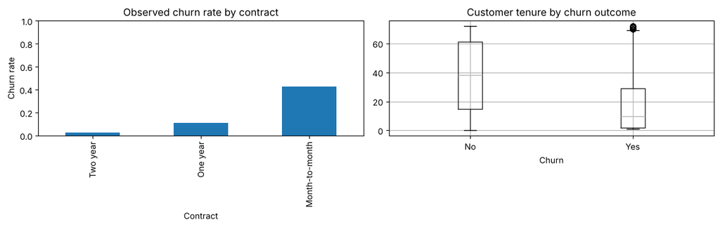

```python
fig, axes = plt.subplots(1, 2, figsize=(12,4))
contract_churn = df.groupby('Contract')['Churn'].apply(lambda s: s.eq('Yes').mean()).sort_values()
contract_churn.plot.bar(ax=axes[0], title='Observed churn rate by contract')
axes[0].set_ylabel('Churn rate'); axes[0].set_ylim(0,1)
df.assign(churned=df['Churn'].eq('Yes')).boxplot(column='tenure', by='Churn', ax=axes[1])
axes[1].set_title('Customer tenure by churn outcome')
plt.suptitle(''); plt.tight_layout(); plt.show()
```

## Findings: contract type and customer tenure

The exploratory analysis found substantial differences in observed churn across contract types and customer tenure.

Customers on month-to-month contracts had the highest churn rate (about 43%), compared with about 11% for one-year contracts and 3% for two-year contracts. Contract type is strongly associated with retention, with longer contracts showing lower observed churn.

Customers who churned generally had shorter relationships with the company. Median tenure was about 10 months for churned customers, compared with 38 months for those who stayed.

**Implications for modelling:** Contract type and tenure are likely to be informative predictors. Their relationship with churn needs further testing through multivariable modelling, feature importance and interaction checks.

**Business implications:** There may be value in looking at early-stage engagement and retention for customers on flexible contracts. These associations should not be read as causal effects.

**Limitations:** This analysis is descriptive and does not adjust for confounders such as pricing, service type, demographics or the interaction between contract and tenure. Later stages add validation, subgroup checks and leakage controls.

## Stage 3: Train/test separation and leakage-safe preprocessing

**Why:** We need an unbiased estimate of how the model may perform on unseen customers. Reserve 20% as a final test set; use only the other 80% for model selection.

**What the code does:** Stratifies by churn so both partitions have similar churn prevalence. Numerical fields use median imputation and scaling; categorical fields use most-frequent imputation and one-hot encoding. All transformations are fitted **inside a pipeline**, separately within each training fold.

**Bias control:** This avoids *data leakage* from test rows into training. `customerID` is excluded. Check for other variables that would only be known **after** churn or at the time of a retention decision. Random splitting cannot prove performance on future customers: real deployment requires a dated, forward-looking holdout.

```python
X = df.drop(columns=['Churn','customerID'])
y = df['Churn'].map({'No':0,'Yes':1}).astype(int)
X_train, X_test, y_train, y_test = train_test_split(X,y,test_size=0.2,stratify=y,random_state=RANDOM_STATE)
num_cols = X_train.select_dtypes(include=np.number).columns.tolist()
cat_cols = X_train.columns.difference(num_cols).tolist()
num_pipe = Pipeline([('imputer',SimpleImputer(strategy='median')),('scaler',StandardScaler())])
cat_pipe = Pipeline([('imputer',SimpleImputer(strategy='most_frequent')),
                     ('onehot',OneHotEncoder(handle_unknown='ignore'))])
preprocess = ColumnTransformer([('num',num_pipe,num_cols),('cat',cat_pipe,cat_cols)])
models = {
 'Dummy baseline': DummyClassifier(strategy='prior'),
 'Logistic regression': LogisticRegression(max_iter=2000,random_state=RANDOM_STATE),
 'Random forest': RandomForestClassifier(n_estimators=250,min_samples_leaf=3,n_jobs=-1,random_state=RANDOM_STATE)
}
cv = StratifiedKFold(n_splits=5,shuffle=True,random_state=RANDOM_STATE)
print('Training:',len(X_train),'Test:',len(X_test),'Positive rate:',round(y.mean(),3))
```

```
Training: 5634 Test: 1409 Positive rate: 0.265
```

## Stage 4: Five-fold stratified cross-validation and model selection

**Why:** A single split can be lucky or unlucky. Five-fold CV repeatedly trains on four training folds and validates on the fifth, then averages the scores.

**Models:** DummyClassifier estimates a no-skill baseline; Logistic Regression is interpretable; Random Forest can capture nonlinear relationships.

**Metrics:** ROC-AUC measures ranking across thresholds. **PR-AUC / average precision** is particularly useful when the positive class (churn) is less common. F1 balances precision and recall at a fixed decision threshold. We select by **training-only CV PR-AUC**.

**Bias control:** Do not select models based on the test set. Report the variability across folds, not only the mean. Model comparison should use identical splits and preprocessing rules. If extensive hyperparameter tuning is added, use nested CV or a separate validation split.

```python
results=[]
for name, estimator in models.items():
    pipe = Pipeline([('prep',preprocess),('model',estimator)])
    scores = cross_validate(pipe,X_train,y_train,cv=cv,
                            scoring={'roc_auc':'roc_auc','pr_auc':'average_precision','f1':'f1'},n_jobs=-1)
    results.append({'model':name, **{metric:float(scores['test_'+metric].mean()) for metric in ['roc_auc','pr_auc','f1']}})
cv_results=pd.DataFrame(results).sort_values('pr_auc',ascending=False)
display(cv_results.round(4))
best_name = cv_results.iloc[0]['model']
print('Selected by CV PR-AUC:',best_name)
```

|  | model | roc_auc | pr_auc | f1 |
| --- | --- | --- | --- | --- |
| 1 | Logistic regression | 0.8461 | 0.6614 | 0.5923 |
| 2 | Random forest | 0.8412 | 0.6504 | 0.5647 |
| 0 | Dummy baseline | 0.5000 | 0.2654 | 0.0000 |

```
Selected by CV PR-AUC: Logistic regression
```

### Fold-to-fold variability

The same five-fold comparison, reporting the standard deviation across folds alongside the mean.

```python
import pandas as pd
from sklearn.base import clone
from sklearn.pipeline import Pipeline
from sklearn.model_selection import StratifiedKFold, cross_validate

cv = StratifiedKFold(
    n_splits=5,
    shuffle=True,
    random_state=42
)

scoring = {
    "ROC_AUC": "roc_auc",
    "PR_AUC": "average_precision",
    "F1": "f1"
}

results = []

for name, estimator in models.items():

    pipeline = Pipeline([
        ("prep", clone(preprocess)),
        ("model", clone(estimator))
    ])

    scores = cross_validate(
        pipeline,
        X_train,
        y_train,
        cv=cv,
        scoring=scoring,
        n_jobs=-1
    )

    row = {"Model": name}

    for metric in scoring:
        values = scores[f"test_{metric}"]
        row[f"{metric}_Mean"] = values.mean()
        row[f"{metric}_SD"] = values.std(ddof=1)

    results.append(row)

cv_summary = pd.DataFrame(results)
display(cv_summary.round(4))
```

|  | Model | ROC_AUC_Mean | ROC_AUC_SD | PR_AUC_Mean | PR_AUC_SD | F1_Mean | F1_SD |
| --- | --- | --- | --- | --- | --- | --- | --- |
| 0 | Dummy baseline | 0.5000 | 0.0000 | 0.2654 | 0.0001 | 0.0000 | 0.0000 |
| 1 | Logistic regression | 0.8461 | 0.0140 | 0.6614 | 0.0218 | 0.5923 | 0.0331 |
| 2 | Random forest | 0.8412 | 0.0105 | 0.6504 | 0.0230 | 0.5647 | 0.0318 |

## Stage 5: Final untouched holdout evaluation

**Why:** The holdout approximates performance on customers not used to develop the model. Evaluate **once** after model selection.

**Confusion matrix:** True positive = correctly flagged churner; false positive = retained customer incorrectly flagged; false negative = churner missed; true negative = correctly identified retained customer.

**Business trade-off:** Higher recall finds more churners but may create more unnecessary outreach. The default 0.50 threshold is a demonstration, **not** an optimised business policy. Choose thresholds using training/validation data and estimated outreach costs, not by repeatedly examining the test set.

**Bias control:** Report both class-specific precision/recall and prevalence-sensitive PR-AUC. Check calibration before treating model scores as meaningful probabilities. A random holdout is not a substitute for out-of-time validation.

```
              precision    recall  f1-score   support

    Retained       0.85      0.89      0.87      1035
     Churned       0.66      0.56      0.60       374

    accuracy                           0.81      1409
   macro avg       0.75      0.73      0.74      1409
weighted avg       0.80      0.81      0.80      1409

Holdout ROC-AUC: 0.8419
Holdout PR-AUC: 0.6334
```

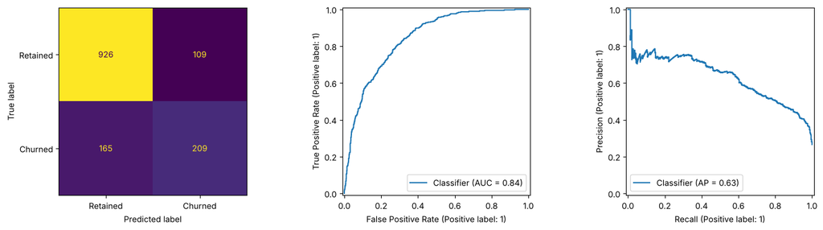

```python
final_model=Pipeline([('prep',preprocess),('model',models[best_name])])
final_model.fit(X_train,y_train)
proba=final_model.predict_proba(X_test)[:,1]
pred=(proba>=0.5).astype(int)
print(classification_report(y_test,pred,target_names=['Retained','Churned'],zero_division=0))
print('Holdout ROC-AUC:',round(roc_auc_score(y_test,proba),4))
print('Holdout PR-AUC:',round(average_precision_score(y_test,proba),4))
fig,axes=plt.subplots(1,3,figsize=(15,4))
ConfusionMatrixDisplay.from_predictions(y_test,pred,ax=axes[0],display_labels=['Retained','Churned'],colorbar=False)
RocCurveDisplay.from_predictions(y_test,proba,ax=axes[1])
PrecisionRecallDisplay.from_predictions(y_test,proba,ax=axes[2])
plt.tight_layout();plt.show()
```

### Interpretation

The model is better at identifying customers who stay (89% recall) than customers who leave (56% recall). Of the customers it flags as likely to churn, 66% actually churned, but it misses about 44% of actual churners.

| Outcome | Count |
| --- | --- |
| Correctly predicted retained | 926 |
| Correctly predicted churned | 209 |
| Incorrectly flagged as churned | 109 |
| Churners missed | 165 |

**Business implication:** The model identified 209 of 374 churned customers and missed 165, so there is room to improve churn detection.

**ROC-AUC (84.19%):** Good ability to separate customers who churn from those who stay.

**Average Precision (63.34%):** Useful for prioritising likely churners, although precision falls as more churners are captured.

**Overall:** 81% accuracy and 84.19% ROC-AUC, but 56% churn recall at the default 0.50 threshold. Next steps are to tune the threshold, try class weighting and feature engineering, and check whether recall can rise without too many false positives. Threshold selection is done on validation data below, not on this test set.

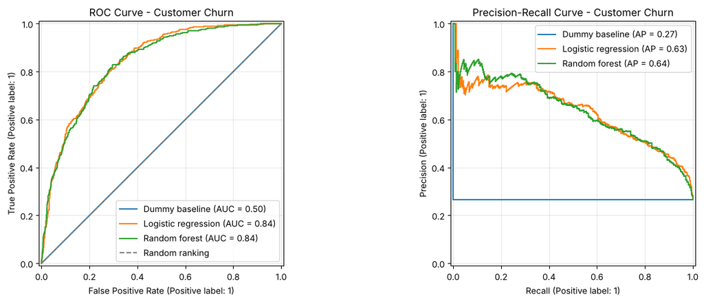

```python
import matplotlib.pyplot as plt
from sklearn.pipeline import Pipeline
from sklearn.base import clone
from sklearn.metrics import (
    RocCurveDisplay,
    PrecisionRecallDisplay
)

# Refit each previously defined model on training data only.
# No test data is used for fitting.
fitted_models = {}

for name, estimator in models.items():
    pipeline = Pipeline([
        ("prep", clone(preprocess)),
        ("model", clone(estimator))
    ])

    pipeline.fit(X_train, y_train)
    fitted_models[name] = pipeline

# Draw both evaluation curves
fig, axes = plt.subplots(1, 2, figsize=(14, 5))

for name, model in fitted_models.items():

    RocCurveDisplay.from_estimator(
        model,
        X_test,
        y_test,
        ax=axes[0],
        name=name
    )

    PrecisionRecallDisplay.from_estimator(
        model,
        X_test,
        y_test,
        ax=axes[1],
        name=name
    )

axes[0].plot(
    [0, 1], [0, 1],
    "--", color="gray",
    label="Random ranking"
)

axes[0].set_title("ROC Curve - Customer Churn")
axes[1].set_title("Precision-Recall Curve - Customer Churn")

axes[0].legend()
axes[1].legend()
axes[0].grid(alpha=0.3)
axes[1].grid(alpha=0.3)

plt.tight_layout()
plt.show()
```

### All models on the holdout (descriptive only)

This comparison is shown for context after the model was already chosen by cross-validation. It was **not** used for model selection.

**ROC curve:** Logistic Regression and Random Forest both reach a ROC-AUC of about 84%, well above the Dummy baseline (50%).

**Precision-Recall curve:** Both models score close to each other on Average Precision (about 63 to 64%), compared with 27% for the Dummy baseline, which equals the churn rate.

**Conclusion:** The two models perform similarly and the differences are small. Logistic Regression was kept because it was selected by cross-validation and is easier to interpret.

## Stage 6: Explainability and feature importance

**Why:** Stakeholders need to understand which recorded inputs help the model make predictions.

**Method:** Permutation importance shuffles one feature in the holdout data and measures the change in average precision. A larger reduction indicates stronger predictive reliance.

**Limitations:** Importance is **not causal**. Correlated variables can mask one another; a predictive variable may be a proxy for an unrecorded factor. Treat the holdout explanation as descriptive, not a basis for retuning the model.

|  | mean_PR_AUC_drop |
| --- | --- |
| tenure | 0.237425 |
| InternetService | 0.078069 |
| MonthlyCharges | 0.062566 |
| Contract | 0.039077 |
| TotalCharges | 0.028339 |
| StreamingMovies | 0.013201 |
| TechSupport | 0.011158 |
| OnlineSecurity | 0.007992 |
| PaymentMethod | 0.005766 |
| PaperlessBilling | 0.003848 |
| DeviceProtection | 0.003803 |
| OnlineBackup | 0.002676 |

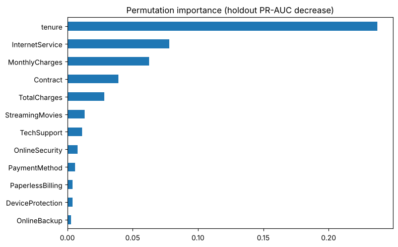

```python
importance=permutation_importance(final_model,X_test,y_test,n_repeats=5,random_state=RANDOM_STATE,scoring='average_precision',n_jobs=-1)
imp=pd.Series(importance.importances_mean,index=X_test.columns).sort_values(ascending=False)
display(imp.head(12).to_frame('mean_PR_AUC_drop'))
imp.head(12).sort_values().plot.barh(figsize=(8,5),title='Permutation importance (holdout PR-AUC decrease)')
plt.tight_layout();plt.show()
```

### Interpretation of permutation importance

| Feature | PR-AUC decrease | Interpretation |
| --- | --- | --- |
| Tenure | 23.74 pts | Most important predictor |
| Internet service | 7.81 pts | Strong contribution |
| Monthly charges | 6.26 pts | Important pricing-related predictor |
| Contract type | 3.91 pts | Moderate contribution |
| Total charges | 2.83 pts | Additional information |

**Key findings:** Tenure is the dominant predictor. Shuffling it reduces average precision by about 24 points, so the model relies heavily on length of service. Internet service type and monthly charges come next. Contract type and total charges also contribute, while online backup, device protection and paperless billing add little on their own.

**Business implications:** Retention work could look at:

- Early engagement with newer customers
- Satisfaction across internet service types
- Pricing and monthly billing
- Customers on flexible contracts

**Limitation:** Permutation importance shows how much performance drops when a feature is shuffled, not whether that feature causes churn. Correlated features, especially tenure and total charges, can affect each other's scores.

## Stage 7: Business prioritisation (scenario, not measured savings)

**Why:** A business may have limited capacity for customer outreach. Ranking predicted risk can help plan a review queue.

**What the code does:** Sorts holdout customers by estimated churn probability and displays a small example. Never publish customer-level identifiers or identifiable predictions from real company data.

**Bias control:** High risk is not the same as high *retention uplift*. Evaluate campaign effectiveness through a randomised trial, and review whether outreach allocation unfairly excludes groups or leads to harmful differential treatment.

```python
ranked=pd.DataFrame({'customerID':df.loc[X_test.index,'customerID'].to_numpy(),
                     'actual_churn':y_test.to_numpy(),'predicted_churn_probability':proba})
ranked=ranked.sort_values('predicted_churn_probability',ascending=False)
for fraction in [0.05,0.10,0.20]:
    top=ranked.head(max(1,int(np.ceil(len(ranked)*fraction))))
    print(f'Top {fraction:.0%}: {len(top)} customers; observed churn rate {top.actual_churn.mean():.1%}; '
          f'capture of test churners {top.actual_churn.sum()/ranked.actual_churn.sum():.1%}')
print('Do not publish customer-level prediction records.')
```

```
Top 5%: 71 customers; observed churn rate 77.5%; capture of test churners 14.7%
Top 10%: 141 customers; observed churn rate 74.5%; capture of test churners 28.1%
Top 20%: 282 customers; observed churn rate 66.0%; capture of test churners 49.7%
Do not publish customer-level prediction records.
```

## Stage 8: Probability calibration and subgroup error audit

**Calibration:** Among customers assigned about 70% risk, roughly 70% should actually churn in a well-calibrated sample. The Brier score measures probability error (lower is better). A calibration plot highlights mismatches; do not fit a calibrator on the final test set.

**Subgroup diagnostics:** Compare **recall** (fraction of actual churners detected) and **false-positive rate** (fraction of retained customers wrongly flagged) by recorded `gender`, `SeniorCitizen`, and `Partner` categories. We suppress rates for small groups (fewer than 30 total or fewer than 10 examples of either outcome). These are descriptive checks, **not** a fairness certification. Consider confidence intervals and legal/contextual review before any deployment.

**Action if disparities appear:** Check data quality and group representation; evaluate performance on new samples; compare threshold and calibration choices on validation data; investigate proxy features; document trade-offs and involve affected stakeholders. Never adjust a model solely to make a test-set fairness metric look better.

```
Brier score (lower is better): 0.1381
```

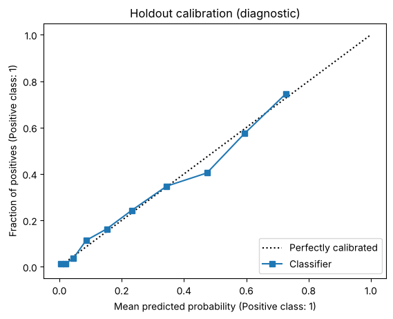

|  | attribute | group | n | churn_n | recall | false_positive_rate | note |
| --- | --- | --- | --- | --- | --- | --- | --- |
| 0 | gender | Female | 687 | 193 | 0.523316 | 0.103239 | Descriptive; uncertainty not quantified |
| 1 | gender | Male | 722 | 181 | 0.596685 | 0.107209 | Descriptive; uncertainty not quantified |
| 2 | SeniorCitizen | 0 | 1187 | 276 | 0.521739 | 0.087816 | Descriptive; uncertainty not quantified |
| 3 | SeniorCitizen | 1 | 222 | 98 | 0.663265 | 0.233871 | Descriptive; uncertainty not quantified |
| 4 | Partner | No | 736 | 248 | 0.633065 | 0.168033 | Descriptive; uncertainty not quantified |
| 5 | Partner | Yes | 673 | 126 | 0.412698 | 0.049360 | Descriptive; uncertainty not quantified |

```python
# Audit prediction errors across groups, with minimum support checks.
# This is diagnostic: differences alone do not prove discrimination.
from sklearn.metrics import precision_score, recall_score, confusion_matrix, brier_score_loss
from sklearn.calibration import CalibrationDisplay

print('Brier score (lower is better):', round(brier_score_loss(y_test, proba), 4))
CalibrationDisplay.from_predictions(y_test, proba, n_bins=10, strategy='quantile')
plt.title('Holdout calibration (diagnostic)')
plt.show()

rows = []
for attribute in ['gender', 'SeniorCitizen', 'Partner']:
    if attribute not in X_test.columns:
        continue
    for group, indices in X_test.groupby(attribute, dropna=False).groups.items():
        positions = X_test.index.get_indexer(indices)
        truth = y_test.iloc[positions].to_numpy()
        guess = pred[positions]
        n = len(truth)
        positives = int(truth.sum())
        negatives = n - positives
        if n < 30 or positives < 10 or negatives < 10:
            rows.append({'attribute': attribute, 'group': str(group), 'n': n,
                         'churn_n': positives, 'recall': np.nan, 'false_positive_rate': np.nan,
                         'note': 'Too few observations for stable comparison'})
            continue
        tn, fp, fn, tp = confusion_matrix(truth, guess, labels=[0, 1]).ravel()
        rows.append({'attribute': attribute, 'group': str(group), 'n': n,
                     'churn_n': positives, 'recall': tp/(tp+fn),
                     'false_positive_rate': fp/(fp+tn), 'note': 'Descriptive; uncertainty not quantified'})
fairness_audit = pd.DataFrame(rows)
display(fairness_audit)
```

### Business impact, calibration and subgroup results

**1. Risk ranking**

| Highest-risk customers | Observed churn rate | Share of all churners captured |
| --- | --- | --- |
| Top 5% | 77.5% | 14.7% |
| Top 10% | 74.5% | 28.1% |
| Top 20% | 66.0% | 49.7% |

Targeting the highest-risk 20% of customers would reach about half of actual churners. That supports targeted retention, but identifying a likely churner does not mean an intervention will keep them.

**2. Calibration**

Brier score: 0.1381 (lower is better). The calibration curve broadly follows the diagonal, so predicted probabilities are reasonably aligned with observed outcomes. There is some overprediction in the 40 to 60% risk range. A baseline comparison is needed to judge how strong this score is.

**3. Subgroup error audit**

| Customer group | Churn recall | False-positive rate |
| --- | --- | --- |
| Female | 52.3% | 10.3% |
| Male | 59.7% | 10.7% |
| Non-senior | 52.2% | 8.8% |
| Senior | 66.3% | 23.4% |
| No partner | 63.3% | 16.8% |
| Has partner | 41.3% | 4.9% |

Performance varies across groups:

- **Senior customers:** higher recall (66.3%) but a much higher false-positive rate (23.4% vs 8.8% for non-seniors)
- **Partner status:** customers with partners have lower recall (41.3%) than those without (63.3%)
- **Gender:** a smaller recall gap of about 7 points between male and female customers

These are descriptive checks without confidence intervals, not a fairness certification.

## Stage 9: Limitations, fairness and responsible use

- **Selection/representation bias:** This sample may not reflect a particular region, energy provider, or future customer base. Compare the deployment population with the training sample.
- **Label bias:** `Churn` reflects recorded departures; verify its operational definition and whether outcomes are consistently captured.
- **Historical bias:** Contract, payment and service variables may encode past business practices and unequal access.
- **Proxy discrimination:** Removing gender or senior-citizen status alone does not guarantee fairness; other features may correlate with them.
- **Measurement bias:** `TotalCharges` blanks and other missing values may not be random; document and test sensitivity to missingness.
- **Evaluation bias:** A random holdout can overstate future performance; use time-based external validation when dated records become available.
- **Fairness:** Compare group-level recall, false-positive rates, precision and calibration with uncertainty and minimum sample sizes. No single fairness metric proves a system is fair.
- **Causality:** Observational associations do not justify claims about what will reduce churn. Test retention strategies prospectively.
- **Privacy:** Use this public learning dataset for GitHub; do not upload proprietary or personally identifying customer data.

**Next steps:** Compare CV standard deviations; test probability calibration; predefine an outreach threshold using validation data; audit group-level error rates; validate on an out-of-time dataset; document a model card and monitoring plan.

## Stage 10: Compare probability calibration methods

Uses out-of-fold predictions on the training data only, so the test set is not used for further tuning.

|  | Method | Brier Score | Log Loss | ROC-AUC | Average Precision |
| --- | --- | --- | --- | --- | --- |
| 0 | Uncalibrated | 0.1351 | 0.4167 | 0.8456 | 0.6583 |
| 1 | Sigmoid | 0.1352 | 0.4168 | 0.8455 | 0.6584 |
| 2 | Isotonic | 0.1355 | 0.4233 | 0.8437 | 0.6548 |

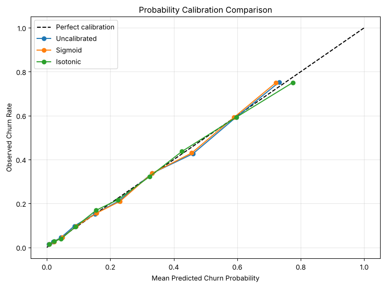

```python
import numpy as np
import pandas as pd
import matplotlib.pyplot as plt

from sklearn.base import clone
from sklearn.pipeline import Pipeline
from sklearn.calibration import (
    CalibratedClassifierCV,
    calibration_curve
)
from sklearn.model_selection import (
    StratifiedKFold,
    cross_val_predict
)
from sklearn.metrics import (
    brier_score_loss,
    log_loss,
    roc_auc_score,
    average_precision_score
)

# Reuse the existing training data and preprocessing
cv = StratifiedKFold(
    n_splits=5,
    shuffle=True,
    random_state=42
)

base_model = Pipeline([
    ("prep", clone(preprocess)),
    ("model", clone(models["Logistic regression"]))
])

# Three candidate approaches
candidates = {
    "Uncalibrated": base_model,
    "Sigmoid": CalibratedClassifierCV(
        estimator=clone(base_model),
        method="sigmoid",
        cv=3
    ),
    "Isotonic": CalibratedClassifierCV(
        estimator=clone(base_model),
        method="isotonic",
        cv=3
    )
}

results = []
probabilities = {}

for name, estimator in candidates.items():

    # Out-of-fold probabilities:
    # each observation is predicted by a model
    # that was not trained on that observation.
    proba = cross_val_predict(
        clone(estimator),
        X_train,
        y_train,
        cv=cv,
        method="predict_proba",
        n_jobs=-1
    )[:, 1]

    probabilities[name] = proba

    results.append({
        "Method": name,
        "Brier Score": brier_score_loss(y_train, proba),
        "Log Loss": log_loss(y_train, proba),
        "ROC-AUC": roc_auc_score(y_train, proba),
        "Average Precision": average_precision_score(
            y_train, proba
        )
    })

calibration_results = pd.DataFrame(results)
display(calibration_results.round(4))

# Plot calibration curves
plt.figure(figsize=(8, 6))

plt.plot(
    [0, 1], [0, 1],
    "--", color="black",
    label="Perfect calibration"
)

for name, proba in probabilities.items():

    observed, predicted = calibration_curve(
        y_train,
        proba,
        n_bins=10,
        strategy="quantile"
    )

    plt.plot(
        predicted,
        observed,
        marker="o",
        label=name
    )

plt.xlabel("Mean Predicted Churn Probability")
plt.ylabel("Observed Churn Rate")
plt.title("Probability Calibration Comparison")
plt.legend()
plt.grid(alpha=0.3)
plt.tight_layout()
plt.show()
```

### Calibration results

The uncalibrated Logistic Regression is already well calibrated, and sigmoid or isotonic calibration does not meaningfully improve it.

| Metric | Uncalibrated | Sigmoid | Isotonic |
| --- | --- | --- | --- |
| Brier score | 0.1351 | 0.1352 | 0.1355 |
| Log loss | 0.4167 | 0.4168 | 0.4233 |
| ROC-AUC | 84.56% | 84.55% | 84.37% |
| Average precision | 65.83% | 65.84% | 65.48% |

All three curves sit close to the diagonal. The uncalibrated model has the best Brier score and log loss, and ROC-AUC and average precision are almost identical across methods.

**Decision:** Keep the uncalibrated Logistic Regression for its reliability, simplicity and interpretability. Calibration should be rechecked on future customer data.

## Stage 11: Outreach threshold selection

With model stability and calibration checked, the next step is to decide which customers to prioritise for retention outreach. Thresholds from 10% to 90% are compared using out-of-fold predictions from the training data, not the test set.

|  | Threshold | Precision | Recall | F1 | False Positive Rate | Customers Flagged (%) |
| --- | --- | --- | --- | --- | --- | --- |
| 0 | 0.10 | 0.400 | 0.942 | 0.562 | 0.510 | 62.442 |
| 1 | 0.15 | 0.438 | 0.912 | 0.592 | 0.423 | 55.254 |
| 2 | 0.20 | 0.475 | 0.855 | 0.611 | 0.341 | 47.746 |
| 3 | 0.25 | 0.510 | 0.817 | 0.628 | 0.284 | 42.528 |
| 4 | 0.30 | 0.541 | 0.767 | 0.634 | 0.235 | 37.611 |
| 5 | 0.35 | 0.571 | 0.717 | 0.635 | 0.195 | 33.351 |
| 6 | 0.40 | 0.594 | 0.664 | 0.627 | 0.164 | 29.641 |
| 7 | 0.45 | 0.624 | 0.601 | 0.612 | 0.131 | 25.559 |
| 8 | 0.50 | 0.653 | 0.543 | 0.593 | 0.104 | 22.080 |
| 9 | 0.55 | 0.685 | 0.486 | 0.569 | 0.081 | 18.832 |
| 10 | 0.60 | 0.710 | 0.397 | 0.509 | 0.058 | 14.821 |
| 11 | 0.65 | 0.754 | 0.306 | 0.435 | 0.036 | 10.756 |
| 12 | 0.70 | 0.780 | 0.211 | 0.333 | 0.022 | 7.188 |
| 13 | 0.75 | 0.848 | 0.101 | 0.181 | 0.007 | 3.159 |
| 14 | 0.80 | 0.918 | 0.030 | 0.058 | 0.001 | 0.870 |
| 15 | 0.85 | 1.000 | 0.001 | 0.003 | 0.000 | 0.035 |
| 16 | 0.90 | 0.000 | 0.000 | 0.000 | 0.000 | 0.000 |

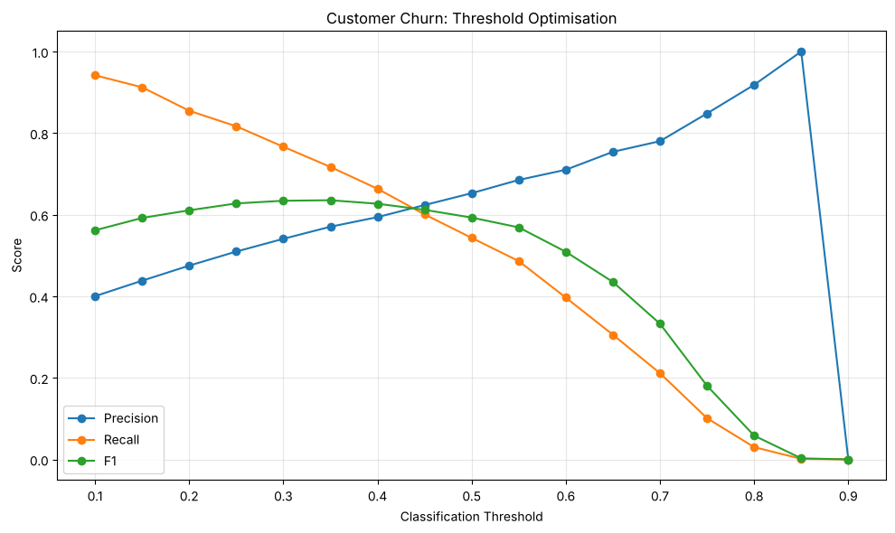

```python
import numpy as np
import pandas as pd
import matplotlib.pyplot as plt

from sklearn.metrics import (
    precision_score,
    recall_score,
    f1_score,
    confusion_matrix
)

# Use out-of-fold probabilities from the calibration stage
# These were generated using training data only.
y_true = np.asarray(y_train)
y_prob = probabilities["Uncalibrated"]

thresholds = np.arange(0.10, 0.91, 0.05)

results = []

for threshold in thresholds:

    y_pred = (y_prob >= threshold).astype(int)

    tn, fp, fn, tp = confusion_matrix(
        y_true, y_pred, labels=[0, 1]
    ).ravel()

    results.append({
        "Threshold": round(threshold, 2),
        "Precision": precision_score(
            y_true, y_pred, zero_division=0
        ),
        "Recall": recall_score(
            y_true, y_pred, zero_division=0
        ),
        "F1": f1_score(
            y_true, y_pred, zero_division=0
        ),
        "False Positive Rate": fp / (fp + tn),
        "Customers Flagged (%)": 100 * y_pred.mean()
    })

threshold_results = pd.DataFrame(results)

display(threshold_results.round(3))

# Plot evaluation metrics
plt.figure(figsize=(10, 6))

for metric in ["Precision", "Recall", "F1"]:
    plt.plot(
        threshold_results["Threshold"],
        threshold_results[metric],
        marker="o",
        label=metric
    )

plt.xlabel("Classification Threshold")
plt.ylabel("Score")
plt.title("Customer Churn: Threshold Optimisation")
plt.legend()
plt.grid(alpha=0.3)
plt.tight_layout()
plt.show()
```

### Threshold findings

35% gives the best F1-score of the thresholds tested.

| Metric | Default (50%) | Selected (35%) |
| --- | --- | --- |
| Precision | 65.3% | 57.1% |
| Recall | 54.3% | 71.7% |
| F1-score | 59.3% | 63.5% |
| False-positive rate | 10.4% | 19.5% |
| Customers flagged | 22.1% | 33.4% |

Lowering the threshold from 50% to 35% raises churn recall by 17.4 points and F1 by 4.2 points. The model flags about a third of customers instead of a fifth, and more retained customers would receive unnecessary outreach.

**Decision:** Use 35% as the provisional F1-based threshold. For a real campaign, the final rule should depend on outreach capacity and cost. A team that can only contact 10% of customers may prefer the top 10% by risk rather than everyone above 35%.

### One-off holdout check of the selected threshold

The 35% threshold was chosen on training data only. Applying it once to the untouched test set shows whether the validation gain carries over. Nothing is tuned on this result.

```python
holdout_proba = final_model.predict_proba(X_test)[:, 1]
rows = []
for t in [0.50, 0.35]:
    p = (holdout_proba >= t).astype(int)
    tn, fp, fn, tp = confusion_matrix(y_test, p, labels=[0, 1]).ravel()
    rows.append({'Threshold': t,
                 'Precision': precision_score(y_test, p, zero_division=0),
                 'Recall': recall_score(y_test, p, zero_division=0),
                 'F1': f1_score(y_test, p, zero_division=0),
                 'False Positive Rate': fp / (fp + tn),
                 'Customers Flagged (%)': 100 * p.mean()})
display(pd.DataFrame(rows).round(3))
```

|  | Threshold | Precision | Recall | F1 | False Positive Rate | Customers Flagged (%) |
| --- | --- | --- | --- | --- | --- | --- |
| 0 | 0.50 | 0.657 | 0.559 | 0.604 | 0.105 | 22.569 |
| 1 | 0.35 | 0.544 | 0.706 | 0.615 | 0.214 | 34.422 |

On the holdout, the 35% threshold raised churn recall from 55.9% to 70.6% and F1 from 60.4% to 61.5%, while the false-positive rate rose from 10.5% to 21.4%. The direction of the validation result holds on unseen customers, although the F1 gain is smaller than in validation.

## Conclusion

This project developed and evaluated machine learning models for predicting telecommunications customer churn using 7,043 customer records.

Logistic Regression emerged as the preferred model, achieving a cross-validated ROC-AUC of 84.61% and Average Precision of 66.14%, outperforming Random Forest and the Dummy baseline.

Feature importance analysis identified customer tenure, internet service type, monthly charges and contract type as important predictors of churn.

Probability calibration analysis indicated that the original Logistic Regression model produced reasonably reliable risk estimates without requiring additional calibration.

Threshold optimisation improved validation churn recall from 54.3% to 71.7% and F1-score from 59.3% to 63.5% by reducing the classification threshold from 50% to 35%. A single holdout check confirmed the recall gain (55.9% to 70.6%), with a smaller F1 improvement (60.4% to 61.5%).

Overall, the findings demonstrate the potential of machine learning to support customer churn risk identification and retention prioritisation. However, further fairness evaluation, independent validation and real-world intervention testing are necessary before operational deployment.